# Masinõpe KNN näitel paketiga mlr

2024-05-11

# Paketid

```r
library(tidyverse)
library(mlr)
```

Infoks: milliseid õpimeetodeid `mlr` veel võimaldab?

```r
# listLearners()$class
# listLearners("classif")$class
```

# 1. Andmed

Loeme sisse osa [Chapel Hill Expert Survey 2014](https://www.chesdata.eu/2014-chapel-hill-expert-survey) andmestikust Euroopa parlamentide erakondade kohta (Ryan Bakker, Erica Edwards, Liesbet Hooghe, Seth Jolly, Gary Marks, Jonathan Polk, Jan Rovny, Marco Steenbergen, and Milada Vachudova. 2015. “2014 Chapel Hill Expert Survey.”); Bruno Castanho Silva @ ECPR Winter School 2020

```r
df <- read.csv("data/ches_2014.csv")
head(df)
```

```
##   cname party_name    lrgen spendvtax immigrate_policy
## 1   sle        NSI 7.846154  78.18182         7.444445
## 2   fra         AC 6.600000  62.00000         6.500000
## 3   fin         KD 6.222222  55.00000         6.142857
## 4   cro        HDZ 7.333334  65.55555         7.142857
## 5   hun     Fidesz 7.928571  56.36364         7.833334
## 6   bul        DBG 6.133333  60.71429         4.538462
```

- cname - riik
- party_name - erakonna lühend
- lrgen - erakonna positsioon 2014. aastal üldise ideoloogilise hoiaku poolest (0 = *Extreme left*, 10 = *Extreme right*)
- spendvtax - seisukoht avalike teenuste parandamise vs maksude vähendamise osas (0 = *Fully in favour of raising taxes to increase public services*, 100 = *Fully in favour of cutting public services to cut taxes*)
- immigrate_policy - seisukoht immigratsioonipoliitika osas (0 = *Fully opposed to a restrictive policy on immigration*, 10 = *Fully in favor of a restrictive policy on immigration*)

Vaatame tunnuste jaotusparameetreid.

```r
psych::describe(df[,3:5])
```

```
##                  vars   n  mean    sd median trimmed   mad  min   max range
## lrgen               1 268  5.29  2.32   5.51    5.34  2.62 0.29 10.00  9.71
## spendvtax           2 268 48.13 20.57  48.61   48.34 22.11 2.00 95.29 93.29
## immigrate_policy    3 268  5.15  2.34   5.00    5.09  2.47 0.47 10.00  9.53
##                   skew kurtosis   se
## lrgen            -0.18    -0.88 0.14
## spendvtax        -0.08    -0.69 1.26
## immigrate_policy  0.18    -0.80 0.14
```

Kas andmeid oleks vaja standardiseerida? Selleks võib mõelda järgnevate küsimuste peale:

- Kas jaotused on võrreldavad?
- Kas hajuvused on võrreldavad?

Eesmärgiks on koostada kNN meetodil mudel, mis klassifitseerib erakonna kas vasak- või parempoolseks. Klassifitseerimise aluseks olevad tunnused peaksid ise olema arvulised, ent klassifitseeriv tunnnus peaks olema **kategoriaalne**. Selleks muudame tunnust *lrgen,* mille algne kuju on arvuline väärtus.

```r
df <- df %>%
  mutate(lrgen = ifelse(lrgen < 5, 'left','right')) %>%
  mutate(lrgen = as.factor(lrgen))

df
```

```
##     cname   party_name lrgen spendvtax immigrate_policy
## 1     sle          NSI right 78.181820        7.4444447
## 2     fra           AC right 61.999998        6.5000000
## 3     fin           KD right 55.000000        6.1428571
## 4     cro          HDZ right 65.555553        7.1428571
## 5     hun       Fidesz right 56.363635        7.8333335
## 6     bul          DBG right 60.714288        4.5384617
## 7     bel          VLD right 83.999996        6.5999999
## 8     bul         NFSB right 40.833335        9.1333332
## 9     fin          VAS  left 20.000000        2.8750000
## 10    pol          PiS right 33.125000        6.1999998
## 11    fra          MPF right 75.555553        9.5555553
## 12    por           PP right 63.333335        8.0000000
## 13    den           SD  left 40.999999        5.5000000
## 14    por           PS  left 38.333333        4.0000000
```

[output cut: 254 more lines]

Klassifitseerimine toimub kahe tunnuse alusel:

- *spendvtax* = position on improving public services vs. reducing taxes.
  - 0 = Fully in favour of raising taxes to increase public services
  - 100 = Fully in favour of cutting public services to cut taxes
- *immigrate_policy* = position on immigration policy.
  - 0 = Fully opposed to a restrictive policy on immigration
  - 10 = Fully in favor of a restrictive policy on immigration

Vaatame, kuidas need tunnused on omavahel ja vasak-parempoolsusega seotud

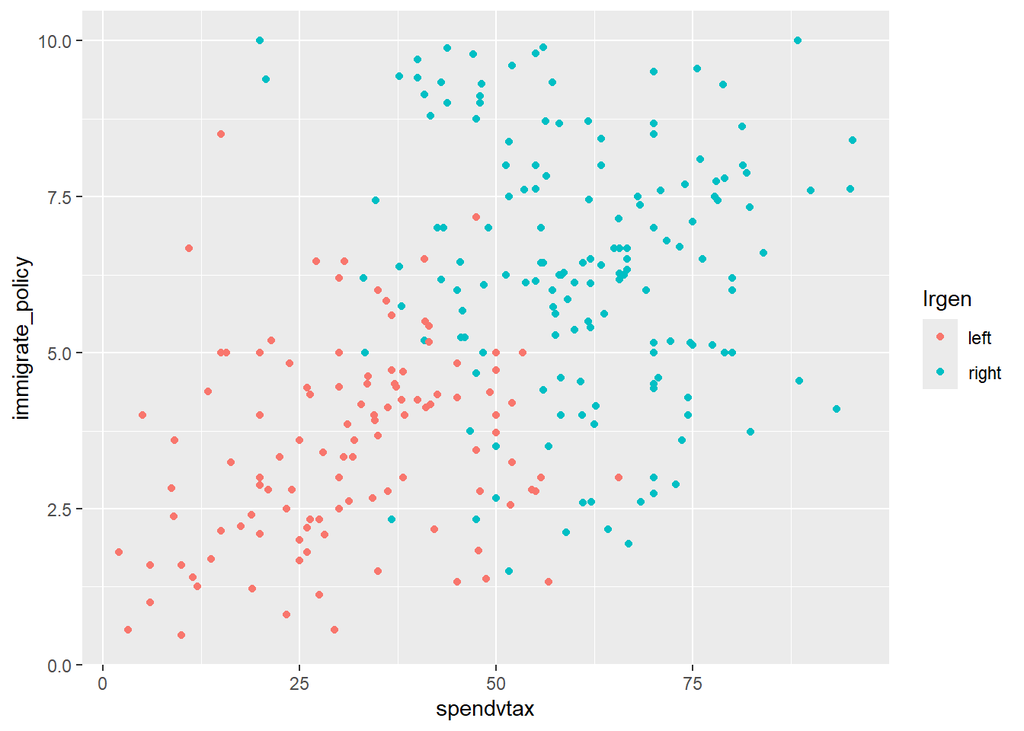

```r
ggplot(df, aes(spendvtax, immigrate_policy, colour = lrgen)) +
  geom_point()
```

Lihtsalt huvi pärast vaatame ka Eesti erakondade paigutust:

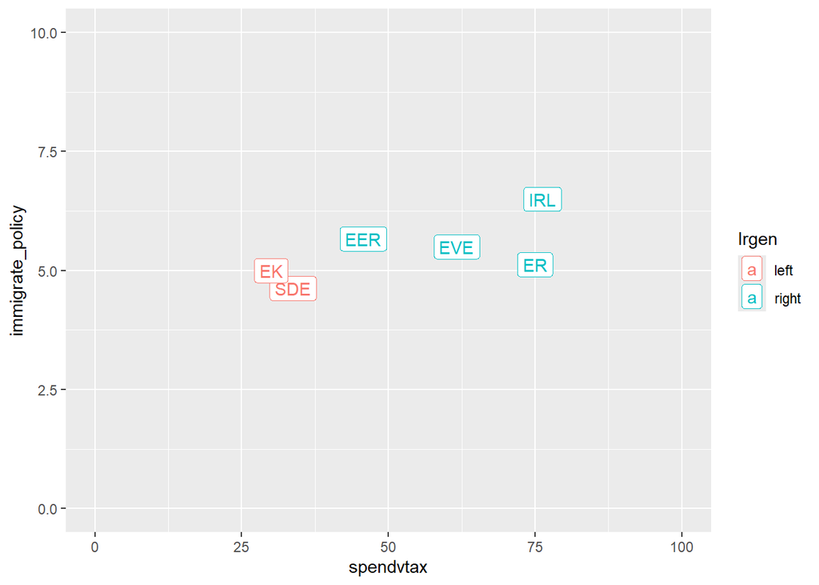

```r
df %>% filter(cname == "est") %>%
  ggplot(aes(spendvtax, immigrate_policy, colour = lrgen, label = party_name)) +
  geom_point() +
  geom_label() +
  xlim(0, 100) +
  ylim(0, 10)
```

Nagu nägime, siis *spendvatx* ja *immigrate_policy* on erinevatel skaaladel, tuleks standardiseerida. Antud juhul sobiks standardiseerimiseks *spendvtax* skaala jagamine 10-ga, sellisel juhul on skaalad ka sisuliselt paremini tõlgendatavad.

```r
df <- df %>%
  mutate(spendvtax = spendvtax / 10)
```

```r
# saanuks siiski ka z-skoorideks teisendamist kasutada
# df <- df %>%
#  mutate(across(where(is.numeric), scale))
```

Koostame mudeli, kus võtame **k** väärtuseks esmalt 17 (lähim paaritu arv ruutjuurele erakondade arvust andmestikus) ja testime selle täpsust. Selleks eraldame andmed mudeli koostamiseks (n-ö treenimiseks/õpetamiseks) ja testimiseks. Juba eelnevalt on andmestikus ridade järjekord juhuslikustatud, nii et saame siin andmed kaheks eraldada lihtsalt reanumbrite järgi.

```r
df <- df %>%
  select(lrgen, spendvtax, immigrate_policy)

train <- df %>%
  slice(1:179)

test <- df %>%
  slice(180:268)
```

# 2. Mudeli koostamine

Kasutame masinõppe meetodeid paketi `mlr` abil, millega saab R-s hõlpsalt KNN-i ja muid masinõppemeetodeid (sh tavalisi regressioonimudeleid) kasutada. Teised sarnased n-ö katuspaketid R-s on `caret` ja `tidymodels`. Paketi `mlr` loogika erinevate masinõppemeetodite puhul on, et kõigepealt paneme paika **ülesande**, mida tahame masinõppega lahendada - antud juhul teatud kahe tunnuse põhjal klassifitseerida erakonnad vasak- ja parempoolseteks. See käib funktsiooniga `makeClassifTask`, kus tuleb defineerida andmed, mida me kasutame (*train*) ja mis on see tunnus, kus on klassikuuluvus.

```r
lrTask <- makeClassifTask(data = train, target = "lrgen")
lrTask
```

```
## Supervised task: train
## Type: classif
## Target: lrgen
## Observations: 179
## Features:
##    numerics     factors     ordered functionals
##           2           0           0           0
## Missings: FALSE
## Has weights: FALSE
## Has blocking: FALSE
## Has coordinates: FALSE
## Classes: 2
##  left right
##    78   101
## Positive class: left
```

Seejärel on vaja defineerida **õpimeetod** ehk valida algoritm, mida klassifitseerimisel kasutada koos vajalike argumentidega ehk hüperparameetrite väärtustega. Käib see siis funktsiooniga `makeLearner` ja meetodiks e. algoritmiks valime *knn*. Hüperarameeter, mida saab seadistada on **k**. Alguses me veel ei tea, milline on kõige nö optimaalsem k väärtus.

```r
knn <- makeLearner("classif.knn", k = 17)
knn
```

```
## Learner classif.knn from package class
## Type: classif
## Name: k-Nearest Neighbor; Short name: knn
## Class: classif.knn
## Properties: twoclass,multiclass,numerics
## Predict-Type: response
## Hyperparameters: k=17
```

Loome mudeli - rakendame eelnevalt defineeritud meetodi sõnastatud ülesandele ja saame mudeli, millega on pmst võimalik tulevikus uute andmete põhjal järeldusi teha (uute erakondade puhul otsustada, kas tegu on vasak- või parempoolse erakonnaga). Mudeli koostamine käib paketis `mlr` funktsiooniga `train`, mille:

- esimene argument on **õpimeetod** (vastav objekt eelnevalt loodud funktsooniga `makeLearner`);
- teine argument **ülesanne** (loodud funktsiooniga `makeClassifTask`, millega eelnevalt defineerisime andmed ja klassi tunnuse).

```r
knnModel <- train(knn, lrTask)
knnModel
```

```
## Model for learner.id=classif.knn; learner.class=classif.knn
## Trained on: task.id = train; obs = 179; features = 2
## Hyperparameters: k=17
```

Sisuliselt uusi andmeid meil ei ole, aga on testandmed (objekt *test*). Saame testandmete peal kontrollida, kui täpselt loodud mudel, mis võtab arvesse 17 lähima erakonna vasak-parempoolsust (k=17), erakondi klassifitseerib. (Millised on lähimad, otsustatakse erakondade positsioonide alusel maksu- ja immigratsiooniküsimustes).

Klassifitseerimine, milline erakond on vasak- ja milline parempoolne, käib sel juhul funktsiooniga `predict`.

Prognoositud väärtusi saame võrrelda tegeliku klassikuuluvusega.

```r
knnProgn <- predict(knnModel, newdata = test)
knnProgn
```

```
## Prediction: 89 observations
## predict.type: response
## threshold:
## time: 0.01
##   truth response
## 1 right    right
## 2 right    right
## 3  left     left
## 4 right    right
## 5 right    right
## 6 right    right
## ... (#rows: 89, #cols: 2)
```

1. Väljundist on näha, et testandmestikus oli 89 vaatlust ehk rida
2. *truth* veerus klassikuuluvuse tegelik väärtus; *response* veerus prognoositud väärtus.

Uurime mudeli täpsust kokkuvõtlikumalt, st kuidas klassifitseeritud väärtused lähevad kokku tegelike väärtustega.

```r
# tegelikud vs porgnoositud väärtused
table(knnProgn$data$truth, knnProgn$data$response)
```

```
##
##         left right
##   left    32     4
##   right    4    49
```

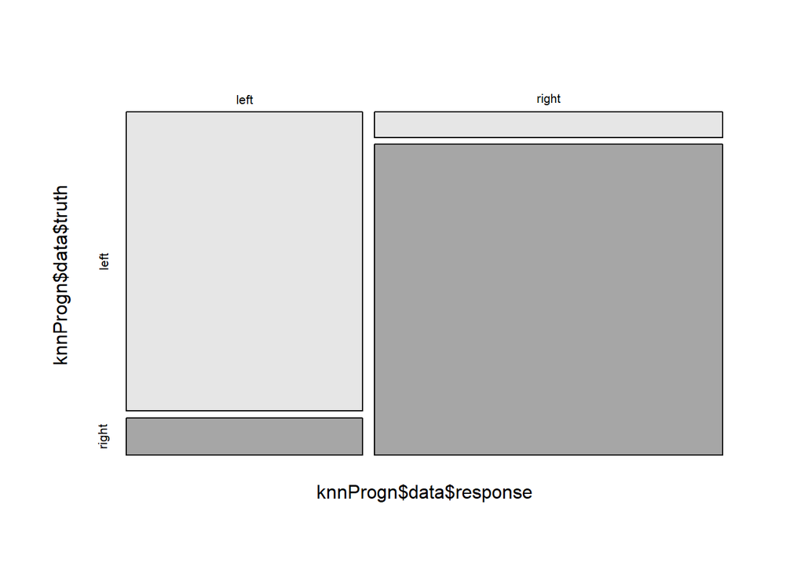

```
##    Cell Contents
## |-------------------------|
## |                   Count |
## |          Column Percent |
## |-------------------------|
##
## ============================================
##                        knnProgn$data$response
## knnProgn$data$truth     left   right   Total
## --------------------------------------------
## left                     32       4      36
##                        88.9%    7.5%
## --------------------------------------------
## right                     4      49      53
##                        11.1%   92.5%
## --------------------------------------------
## Total                    36      53      89
##                        40.4%   59.6%
## ============================================
```

```r
# tegelikud vs porgnoositud väärtused - risttabel
descr::crosstab(knnProgn$data$truth, knnProgn$data$response, prop.c = T)
```

```r
#mudel
performance(knnProgn, measures = list(mmce, acc))
```

```
##       mmce        acc
## 0.08988764 0.91011236
```

Risttabel võimaldab uurida, kui palju on valenegatiivsete ja valepositiivsete hulk. Sõltuvalt uurimisprobleemist võib meid huvitada rohkem valenegatiivsete või valepositiivsete hulk.

- Valepositiivne - ilmneb siis, kui mudel ennustab positiivset tulemust, kuid tegelik tulemus on negatiivne. Antud juhul on positiivne väärtus *left*.
- Valenegatiivne - ilmneb siis, kui mudel ennustab negatiivset tulemust, kuid tegelik tulemus on positiivne.
1. Tabelist näeme, kui paljude erakondade puhul prognoos läks täppi –> antud juhul 32 (left) ja 49 (right) puhul läks prognoos täppi. 8 juhul ei läinud täppi – 4 prognoositi vasakuks, aga olid parem; 4 prognoositi paremaks, aga olid vasak.
2. Kui vaatame prognoose, siis nendest erakondadest, kes prognoositi vasakpoolseks, siis nendest 89% olid vasakpoolsed ja 11% tegelikult parempoolsed.

**mmce** - keskmine liigitamise viga (*mean misclassification error*). Kui suure osa moodustab valenegatiivsete ja valepositiivsete summa kõigist prognoosidest.

**acc** - *accuracy*. eelmise vastandväärtus, täpsete prognooside osakaal.

Praegu klassifitseeriksime ühe erakonna kümnest valesti - kuidas tundub?

# 3. Valideerimine

Siiamaani oleme koostanud mudeli ja selle täpsust ka uurinud. Treening- ja testandmestiku lõime juhuslikkuse alusel algsest andmestikust, aga kui me võtaksime mingi muu osa sellest andmestikust ehk juhuslikkuse alusel valiksime mingid muud erakonnad testandmestiku jaoks, siis võib juhtuda, et saame teistsuguse hinnangu. Seetõttu peaks valideerimist tegema natuke täpsemini.

## *Holdout validation* e. ühekordne valideerimine

Pmst seda juba tegime, kugigi paketi `mlr` funktsioonid annavad ehk mugavamaid võimalusi (nt klassifitseeriva tunnuse alusel kihistamine).

Defineerime meetodi (`holdout`), kui suur osa andmestikust kuulub treeningkogumisse (`split`), kas kihistada valimit (`stratify = T`). Viimane tähendab seda, et kui võtta lihtsalt juhuvalim andmestikust, siis olenevalt juhuslikkusest sinna võib sattuda rohkem või vähem nt vasakpoolseid erakondi, siis kihistamine tähendabki seda, et me ei võta mitte juhuvalimit, vaid võtame kihtvalimi ehk stratifitseeriva tunnuse (vasak-/parempoolsus), siis jagame selle andmestiku kaheks (tunnuseks 2 valikut) ja teeme kummastki kategooriast juhusliku valiku. See tagab selle, et nii treening- kui ka testkogumis on vasak- ja parempoolsete tasakaal sarnane, nagu on see algses andmestikus.

```r
holdout <- makeResampleDesc(method = "Holdout", split = 2/3, stratify = T)
holdout
```

```
## Resample description: holdout with 0.67 split rate.
## Predict: test
## Stratification: TRUE
```

Defineerime uue **ülesande** (`makeClassifTask`), sest eelnevalt jaotasime ise andmestiku kaheks osaks ja õppeülesandeks valisime ainult ühe osa algsest andmestikust; siin saame ülesandes ära määratleda kogu andmestiku ja selle jaotamine õppe- ja testvalimiks toimub valideerimise käigus ehk koostamine toimub juhuslikkuse alusel.

```r
lr_valid <- makeClassifTask(data = df, target = "lrgen")
lr_valid
```

```
## Supervised task: df
## Type: classif
## Target: lrgen
## Observations: 268
## Features:
##    numerics     factors     ordered functionals
##           2           0           0           0
## Missings: FALSE
## Has weights: FALSE
## Has blocking: FALSE
## Has coordinates: FALSE
## Classes: 2
##  left right
##   114   154
## Positive class: left
```

Funktsiooniga `resample` saame läbi teha selle mudeli koos valideerimisega. Ette anname **õpimeetodi** (algselt defineeritud *knn*); **ülesande**; paneme paika selle, kust tuleb **valideerimise eeskiri** (`resampling`) ja paneme kirja **mudeli täpsuse näitajad** (`measures`).

Juhuslikkuse tõttu saame siin tõenäoliselt erinevad tulemused. Kui soovida enda tulemust korrata, siis oleks hea kasutada `set.seed()`.

```r
set.seed(123)
holdoutvalid <- resample(learner = knn,
                         task = lr_valid,
                         resampling = holdout, # valideerimine
                         measures = list(mmce, acc))
```

```
## Resampling: holdout
```

```
## Measures:             mmce      acc
```

```
## [Resample] iter 1:    0.1111111 0.8888889
```

```
## Aggregated Result: mmce.test.mean=0.1111111,acc.test.mean=0.8888889
```

```r
holdoutvalid
```

```
## Resample Result
## Task: df
## Learner: classif.knn
## Aggr perf: mmce.test.mean=0.1111111,acc.test.mean=0.8888889
## Runtime: 0.00471401
```

```r
# mudeli täpsuse näitajad
holdoutvalid$aggr
```

```
## mmce.test.mean  acc.test.mean
##      0.1111111      0.8888889
```

```r
# confusion matrix
calculateConfusionMatrix(holdoutvalid$pred, relative = T) # testkogumi alusel saadud prognoositud väärtused, tahame suhtelisi osakaale
```

```
## Relative confusion matrix (normalized by row/column):
##         predicted
## true     left      right     -err.-
##   left   0.89/0.85 0.11/0.08 0.11
##   right  0.12/0.15 0.88/0.92 0.12
##   -err.-      0.15      0.08 0.11
##
##
## Absolute confusion matrix:
##         predicted
## true     left right -err.-
##   left     34     4      4
##   right     6    46      6
##   -err.-    6     4     10
```

*Confusion Matrixis* on 2 tabelit: suhtelised jaotused ja absoluutarvud. Read tähistavad tegelikke klasse, veerud tähistavad prognoositud klasse.

Sisuliseks tõlgendamiseks saame kasutada valepositiivsete ja valenegatiivsete osakaalu.

- Nt nendest erakondadest, kes on vasakpoolsed, õigesti prognoositi 89%, 11% puhul prognoositi nad parempoolseteks.
- Nendest erakondadest, kes olid parempoolsed, õigesti prognoositi 88% ja 12% vasakpoolseteks.
- Selliste tulemuste puhul saab öelda, et mudel prognoosib mõlemat kategooriat justkui sama hästi.

See oli siis ühekordne valideerimine.

## *k-fold CV*

k-foldi puhul on `resample` funktsiooni mõned k-väärtused sisseehitatud (nt cv5, cv3, cv10) - sel juhul ei pea eelnevalt ise valideerimisskeemi valideerima.

```r
set.seed(22)
kFold5valid <- resample(learner = knn,
                        task = lr_valid,
                        resampling = cv5,
                        measures = list(mmce, acc))
```

```
## Resampling: cross-validation
```

```
## Measures:             mmce      acc
```

```
## [Resample] iter 1:    0.0754717 0.9245283
```

```
## [Resample] iter 2:    0.0943396 0.9056604
```

```
## [Resample] iter 3:    0.1296296 0.8703704
```

```
## [Resample] iter 4:    0.1296296 0.8703704
```

```
## [Resample] iter 5:    0.0925926 0.9074074
```

```
## Aggregated Result: mmce.test.mean=0.1043326,acc.test.mean=0.8956674
```

```r
kFold5valid
```

```
## Resample Result
## Task: df
## Learner: classif.knn
## Aggr perf: mmce.test.mean=0.1043326,acc.test.mean=0.8956674
## Runtime: 0.015965
```

Eelnevas käsus on argumendi resampling väärtuse `cv5` näol tegu sisseehitatud k-fold valideerimise valikuskeemiga, kus andmestik jaotatakse k = 5 osaks. Näeme, et valideerimist on läbi viidud 5 korda. Näidatud on ka kõigi valideerimiste peale keskmised tulemused mudeli kohta.

Kui tahame anda k-le muu väärtuse, tuleb eelnevalt defineerida valikuskeem funktsiooniga `makeResampleDesc`. Valideerimise saab lisaks läbi teha mitu korda, siis on tegu n-ö *repeated k-fold CV*-ga (iter = folds * reps), vaikeseadena `reps = 10`.

Antud juhul tehakse valideerimine läbi 5*4 korda.

```r
kFold5_4 <- makeResampleDesc(method = "RepCV", folds = 5, reps = 4, stratify = T)
kFold5_4
```

```
## Resample description: repeated cross-validation with 20 iterations: 5 folds and 4 reps.
## Predict: test
## Stratification: TRUE
```

```r
set.seed(12)
kFold5_4valid <- resample(learner = knn,
                          task = lr_valid,
                          resampling = kFold5_4,
                          measures = list(mmce, acc))
```

```
## Resampling: repeated cross-validation
```

```
## Measures:             mmce      acc
```

```
## [Resample] iter 1:    0.0925926 0.9074074
```

```
## [Resample] iter 2:    0.1132075 0.8867925
```

```
## [Resample] iter 3:    0.1111111 0.8888889
```

```
## [Resample] iter 4:    0.1111111 0.8888889
```

```
## [Resample] iter 5:    0.0754717 0.9245283
```

```
## [Resample] iter 6:    0.0769231 0.9230769
```

```
## [Resample] iter 7:    0.0740741 0.9259259
```

```
## [Resample] iter 8:    0.1111111 0.8888889
```

```
## [Resample] iter 9:    0.1481481 0.8518519
```

```
## [Resample] iter 10:   0.0925926 0.9074074
```

```
## [Resample] iter 11:   0.1111111 0.8888889
```

```
## [Resample] iter 12:   0.1481481 0.8518519
```

```
## [Resample] iter 13:   0.1111111 0.8888889
```

```
## [Resample] iter 14:   0.0555556 0.9444444
```

```
## [Resample] iter 15:   0.1153846 0.8846154
```

```
## [Resample] iter 16:   0.0925926 0.9074074
```

```
## [Resample] iter 17:   0.0943396 0.9056604
```

```
## [Resample] iter 18:   0.1111111 0.8888889
```

```
## [Resample] iter 19:   0.1296296 0.8703704
```

```
## [Resample] iter 20:   0.1132075 0.8867925
```

```
## Aggregated Result: mmce.test.mean=0.1044267,acc.test.mean=0.8955733
```

```r
kFold5_4valid
```

```
## Resample Result
## Task: df
## Learner: classif.knn
## Aggr perf: mmce.test.mean=0.1044267,acc.test.mean=0.8955733
## Runtime: 0.067714
```

```r
calculateConfusionMatrix(kFold5_4valid$pred, relative = T)
```

```
## Relative confusion matrix (normalized by row/column):
##         predicted
## true     left      right     -err.-
##   left   0.89/0.86 0.11/0.08 0.11
##   right  0.10/0.14 0.90/0.92 0.10
##   -err.-      0.14      0.08 0.10
##
##
## Absolute confusion matrix:
##         predicted
## true     left right -err.-
##   left    408    48     48
##   right    64   552     64
##   -err.-   64    48    112
```

## *LOOCV*

Kõigepealt defineerimine valideerimisskeemi.

```r
LOO <- makeResampleDesc(method = "LOO")
LOO
```

```
## Resample description: LOO with NA iterations.
## Predict: test
## Stratification: FALSE
```

Erakondi ehk andmeridu on suhteliselt vähe, seetõttu ei võta siin *LOOCV* kuigi kaua aega.

```r
set.seed(12)
LOOvalid <- resample(learner = knn,
                     task = lr_valid,
                     resampling = LOO,
                     measures = list(mmce, acc))
```

```
## Resampling: LOO
```

```
## Measures:             mmce      acc
```

```
## [Resample] iter 1:    0.0000000 1.0000000
```

```
## [Resample] iter 2:    0.0000000 1.0000000
```

```
## [Resample] iter 3:    0.0000000 1.0000000
```

```
## [Resample] iter 4:    0.0000000 1.0000000
```

```
## [Resample] iter 5:    0.0000000 1.0000000
```

```
## [Resample] iter 6:    0.0000000 1.0000000
```

```
## [Resample] iter 7:    0.0000000 1.0000000
```

```
## [Resample] iter 8:    0.0000000 1.0000000
```

```
## [Resample] iter 9:    0.0000000 1.0000000
```

```
## [Resample] iter 10:   1.0000000 0.0000000
```

```
## [Resample] iter 11:   0.0000000 1.0000000
```

```
## [Resample] iter 12:   0.0000000 1.0000000
```

```
## [Resample] iter 13:   1.0000000 0.0000000
```

```
## [Resample] iter 14:   0.0000000 1.0000000
```

```
## [Resample] iter 15:   0.0000000 1.0000000
```

```
## [Resample] iter 16:   0.0000000 1.0000000
```

```
## [Resample] iter 17:   0.0000000 1.0000000
```

```
## [Resample] iter 18:   0.0000000 1.0000000
```

```
## [Resample] iter 19:   0.0000000 1.0000000
```

```
## [Resample] iter 20:   0.0000000 1.0000000
```

```
## [Resample] iter 21:   0.0000000 1.0000000
```

```
## [Resample] iter 22:   0.0000000 1.0000000
```

```
## [Resample] iter 23:   0.0000000 1.0000000
```

```
## [Resample] iter 24:   0.0000000 1.0000000
```

```
## [Resample] iter 25:   0.0000000 1.0000000
```

```
## [Resample] iter 26:   0.0000000 1.0000000
```

```
## [Resample] iter 27:   0.0000000 1.0000000
```

```
## [Resample] iter 28:   0.0000000 1.0000000
```

```
## [Resample] iter 29:   0.0000000 1.0000000
```

```
## [Resample] iter 30:   0.0000000 1.0000000
```

```
## [Resample] iter 31:   1.0000000 0.0000000
```

```
## [Resample] iter 32:   0.0000000 1.0000000
```

```
## [Resample] iter 33:   0.0000000 1.0000000
```

```
## [Resample] iter 34:   0.0000000 1.0000000
```

```
## [Resample] iter 35:   0.0000000 1.0000000
```

```
## [Resample] iter 36:   0.0000000 1.0000000
```

```
## [Resample] iter 37:   0.0000000 1.0000000
```

```
## [Resample] iter 38:   0.0000000 1.0000000
```

```
## [Resample] iter 39:   0.0000000 1.0000000
```

```
## [Resample] iter 40:   0.0000000 1.0000000
```

```
## [Resample] iter 41:   0.0000000 1.0000000
```

```
## [Resample] iter 42:   0.0000000 1.0000000
```

```
## [Resample] iter 43:   0.0000000 1.0000000
```

```
## [Resample] iter 44:   0.0000000 1.0000000
```

```
## [Resample] iter 45:   0.0000000 1.0000000
```

```
## [Resample] iter 46:   0.0000000 1.0000000
```

```
## [Resample] iter 47:   0.0000000 1.0000000
```

```
## [Resample] iter 48:   0.0000000 1.0000000
```

```
## [Resample] iter 49:   0.0000000 1.0000000
```

```
## [Resample] iter 50:   0.0000000 1.0000000
```

```
## [Resample] iter 51:   0.0000000 1.0000000
```

```
## [Resample] iter 52:   0.0000000 1.0000000
```

```
## [Resample] iter 53:   1.0000000 0.0000000
```

```
## [Resample] iter 54:   1.0000000 0.0000000
```

```
## [Resample] iter 55:   0.0000000 1.0000000
```

```
## [Resample] iter 56:   0.0000000 1.0000000
```

```
## [Resample] iter 57:   0.0000000 1.0000000
```

```
## [Resample] iter 58:   0.0000000 1.0000000
```

```
## [Resample] iter 59:   0.0000000 1.0000000
```

```
## [Resample] iter 60:   1.0000000 0.0000000
```

```
## [Resample] iter 61:   0.0000000 1.0000000
```

```
## [Resample] iter 62:   0.0000000 1.0000000
```

```
## [Resample] iter 63:   0.0000000 1.0000000
```

```
## [Resample] iter 64:   1.0000000 0.0000000
```

```
## [Resample] iter 65:   1.0000000 0.0000000
```

```
## [Resample] iter 66:   0.0000000 1.0000000
```

```
## [Resample] iter 67:   0.0000000 1.0000000
```

```
## [Resample] iter 68:   0.0000000 1.0000000
```

```
## [Resample] iter 69:   0.0000000 1.0000000
```

```
## [Resample] iter 70:   0.0000000 1.0000000
```

```
## [Resample] iter 71:   0.0000000 1.0000000
```

```
## [Resample] iter 72:   0.0000000 1.0000000
```

```
## [Resample] iter 73:   0.0000000 1.0000000
```

```
## [Resample] iter 74:   1.0000000 0.0000000
```

```
## [Resample] iter 75:   1.0000000 0.0000000
```

```
## [Resample] iter 76:   0.0000000 1.0000000
```

```
## [Resample] iter 77:   0.0000000 1.0000000
```

```
## [Resample] iter 78:   0.0000000 1.0000000
```

```
## [Resample] iter 79:   1.0000000 0.0000000
```

```
## [Resample] iter 80:   0.0000000 1.0000000
```

```
## [Resample] iter 81:   0.0000000 1.0000000
```

```
## [Resample] iter 82:   0.0000000 1.0000000
```

```
## [Resample] iter 83:   0.0000000 1.0000000
```

```
## [Resample] iter 84:   0.0000000 1.0000000
```

```
## [Resample] iter 85:   0.0000000 1.0000000
```

```
## [Resample] iter 86:   0.0000000 1.0000000
```

```
## [Resample] iter 87:   0.0000000 1.0000000
```

```
## [Resample] iter 88:   0.0000000 1.0000000
```

```
## [Resample] iter 89:   0.0000000 1.0000000
```

```
## [Resample] iter 90:   0.0000000 1.0000000
```

```
## [Resample] iter 91:   0.0000000 1.0000000
```

```
## [Resample] iter 92:   0.0000000 1.0000000
```

```
## [Resample] iter 93:   0.0000000 1.0000000
```

```
## [Resample] iter 94:   0.0000000 1.0000000
```

```
## [Resample] iter 95:   0.0000000 1.0000000
```

```
## [Resample] iter 96:   0.0000000 1.0000000
```

```
## [Resample] iter 97:   0.0000000 1.0000000
```

```
## [Resample] iter 98:   1.0000000 0.0000000
```

```
## [Resample] iter 99:   1.0000000 0.0000000
```

```
## [Resample] iter 100:  0.0000000 1.0000000
```

```
## [Resample] iter 101:  0.0000000 1.0000000
```

```
## [Resample] iter 102:  1.0000000 0.0000000
```

```
## [Resample] iter 103:  0.0000000 1.0000000
```

```
## [Resample] iter 104:  0.0000000 1.0000000
```

```
## [Resample] iter 105:  0.0000000 1.0000000
```

```
## [Resample] iter 106:  1.0000000 0.0000000
```

```
## [Resample] iter 107:  1.0000000 0.0000000
```

```
## [Resample] iter 108:  1.0000000 0.0000000
```

```
## [Resample] iter 109:  0.0000000 1.0000000
```

```
## [Resample] iter 110:  0.0000000 1.0000000
```

```
## [Resample] iter 111:  0.0000000 1.0000000
```

```
## [Resample] iter 112:  0.0000000 1.0000000
```

```
## [Resample] iter 113:  0.0000000 1.0000000
```

```
## [Resample] iter 114:  0.0000000 1.0000000
```

```
## [Resample] iter 115:  0.0000000 1.0000000
```

```
## [Resample] iter 116:  0.0000000 1.0000000
```

```
## [Resample] iter 117:  0.0000000 1.0000000
```

```
## [Resample] iter 118:  0.0000000 1.0000000
```

```
## [Resample] iter 119:  0.0000000 1.0000000
```

```
## [Resample] iter 120:  0.0000000 1.0000000
```

```
## [Resample] iter 121:  0.0000000 1.0000000
```

```
## [Resample] iter 122:  0.0000000 1.0000000
```

```
## [Resample] iter 123:  0.0000000 1.0000000
```

```
## [Resample] iter 124:  0.0000000 1.0000000
```

```
## [Resample] iter 125:  0.0000000 1.0000000
```

```
## [Resample] iter 126:  0.0000000 1.0000000
```

```
## [Resample] iter 127:  0.0000000 1.0000000
```

```
## [Resample] iter 128:  0.0000000 1.0000000
```

```
## [Resample] iter 129:  0.0000000 1.0000000
```

```
## [Resample] iter 130:  0.0000000 1.0000000
```

```
## [Resample] iter 131:  0.0000000 1.0000000
```

```
## [Resample] iter 132:  1.0000000 0.0000000
```

```
## [Resample] iter 133:  0.0000000 1.0000000
```

```
## [Resample] iter 134:  0.0000000 1.0000000
```

```
## [Resample] iter 135:  1.0000000 0.0000000
```

```
## [Resample] iter 136:  0.0000000 1.0000000
```

```
## [Resample] iter 137:  0.0000000 1.0000000
```

```
## [Resample] iter 138:  0.0000000 1.0000000
```

```
## [Resample] iter 139:  0.0000000 1.0000000
```

```
## [Resample] iter 140:  0.0000000 1.0000000
```

```
## [Resample] iter 141:  0.0000000 1.0000000
```

```
## [Resample] iter 142:  0.0000000 1.0000000
```

```
## [Resample] iter 143:  0.0000000 1.0000000
```

```
## [Resample] iter 144:  0.0000000 1.0000000
```

```
## [Resample] iter 145:  0.0000000 1.0000000
```

```
## [Resample] iter 146:  0.0000000 1.0000000
```

```
## [Resample] iter 147:  0.0000000 1.0000000
```

```
## [Resample] iter 148:  0.0000000 1.0000000
```

```
## [Resample] iter 149:  0.0000000 1.0000000
```

```
## [Resample] iter 150:  0.0000000 1.0000000
```

```
## [Resample] iter 151:  0.0000000 1.0000000
```

```
## [Resample] iter 152:  1.0000000 0.0000000
```

```
## [Resample] iter 153:  0.0000000 1.0000000
```

```
## [Resample] iter 154:  0.0000000 1.0000000
```

```
## [Resample] iter 155:  0.0000000 1.0000000
```

```
## [Resample] iter 156:  0.0000000 1.0000000
```

```
## [Resample] iter 157:  0.0000000 1.0000000
```

```
## [Resample] iter 158:  0.0000000 1.0000000
```

```
## [Resample] iter 159:  0.0000000 1.0000000
```

```
## [Resample] iter 160:  0.0000000 1.0000000
```

```
## [Resample] iter 161:  0.0000000 1.0000000
```

```
## [Resample] iter 162:  0.0000000 1.0000000
```

```
## [Resample] iter 163:  0.0000000 1.0000000
```

```
## [Resample] iter 164:  0.0000000 1.0000000
```

```
## [Resample] iter 165:  0.0000000 1.0000000
```

```
## [Resample] iter 166:  0.0000000 1.0000000
```

```
## [Resample] iter 167:  1.0000000 0.0000000
```

```
## [Resample] iter 168:  0.0000000 1.0000000
```

```
## [Resample] iter 169:  0.0000000 1.0000000
```

```
## [Resample] iter 170:  0.0000000 1.0000000
```

```
## [Resample] iter 171:  0.0000000 1.0000000
```

```
## [Resample] iter 172:  0.0000000 1.0000000
```

```
## [Resample] iter 173:  0.0000000 1.0000000
```

```
## [Resample] iter 174:  0.0000000 1.0000000
```

```
## [Resample] iter 175:  0.0000000 1.0000000
```

```
## [Resample] iter 176:  0.0000000 1.0000000
```

```
## [Resample] iter 177:  0.0000000 1.0000000
```

```
## [Resample] iter 178:  0.0000000 1.0000000
```

```
## [Resample] iter 179:  0.0000000 1.0000000
```

```
## [Resample] iter 180:  0.0000000 1.0000000
```

```
## [Resample] iter 181:  0.0000000 1.0000000
```

```
## [Resample] iter 182:  0.0000000 1.0000000
```

```
## [Resample] iter 183:  0.0000000 1.0000000
```

```
## [Resample] iter 184:  0.0000000 1.0000000
```

```
## [Resample] iter 185:  0.0000000 1.0000000
```

```
## [Resample] iter 186:  0.0000000 1.0000000
```

```
## [Resample] iter 187:  0.0000000 1.0000000
```

```
## [Resample] iter 188:  0.0000000 1.0000000
```

```
## [Resample] iter 189:  0.0000000 1.0000000
```

```
## [Resample] iter 190:  0.0000000 1.0000000
```

```
## [Resample] iter 191:  0.0000000 1.0000000
```

```
## [Resample] iter 192:  0.0000000 1.0000000
```

```
## [Resample] iter 193:  1.0000000 0.0000000
```

```
## [Resample] iter 194:  0.0000000 1.0000000
```

```
## [Resample] iter 195:  0.0000000 1.0000000
```

```
## [Resample] iter 196:  0.0000000 1.0000000
```

```
## [Resample] iter 197:  0.0000000 1.0000000
```

```
## [Resample] iter 198:  0.0000000 1.0000000
```

```
## [Resample] iter 199:  0.0000000 1.0000000
```

```
## [Resample] iter 200:  0.0000000 1.0000000
```

```
## [Resample] iter 201:  0.0000000 1.0000000
```

```
## [Resample] iter 202:  0.0000000 1.0000000
```

```
## [Resample] iter 203:  0.0000000 1.0000000
```

```
## [Resample] iter 204:  0.0000000 1.0000000
```

```
## [Resample] iter 205:  0.0000000 1.0000000
```

```
## [Resample] iter 206:  0.0000000 1.0000000
```

```
## [Resample] iter 207:  0.0000000 1.0000000
```

```
## [Resample] iter 208:  0.0000000 1.0000000
```

```
## [Resample] iter 209:  0.0000000 1.0000000
```

```
## [Resample] iter 210:  0.0000000 1.0000000
```

```
## [Resample] iter 211:  1.0000000 0.0000000
```

```
## [Resample] iter 212:  0.0000000 1.0000000
```

```
## [Resample] iter 213:  0.0000000 1.0000000
```

```
## [Resample] iter 214:  0.0000000 1.0000000
```

```
## [Resample] iter 215:  0.0000000 1.0000000
```

```
## [Resample] iter 216:  0.0000000 1.0000000
```

```
## [Resample] iter 217:  1.0000000 0.0000000
```

```
## [Resample] iter 218:  0.0000000 1.0000000
```

```
## [Resample] iter 219:  0.0000000 1.0000000
```

```
## [Resample] iter 220:  0.0000000 1.0000000
```

```
## [Resample] iter 221:  0.0000000 1.0000000
```

```
## [Resample] iter 222:  0.0000000 1.0000000
```

```
## [Resample] iter 223:  0.0000000 1.0000000
```

```
## [Resample] iter 224:  0.0000000 1.0000000
```

```
## [Resample] iter 225:  0.0000000 1.0000000
```

```
## [Resample] iter 226:  0.0000000 1.0000000
```

```
## [Resample] iter 227:  0.0000000 1.0000000
```

```
## [Resample] iter 228:  0.0000000 1.0000000
```

```
## [Resample] iter 229:  0.0000000 1.0000000
```

```
## [Resample] iter 230:  0.0000000 1.0000000
```

```
## [Resample] iter 231:  0.0000000 1.0000000
```

```
## [Resample] iter 232:  0.0000000 1.0000000
```

```
## [Resample] iter 233:  0.0000000 1.0000000
```

```
## [Resample] iter 234:  0.0000000 1.0000000
```

```
## [Resample] iter 235:  0.0000000 1.0000000
```

```
## [Resample] iter 236:  0.0000000 1.0000000
```

```
## [Resample] iter 237:  0.0000000 1.0000000
```

```
## [Resample] iter 238:  0.0000000 1.0000000
```

```
## [Resample] iter 239:  0.0000000 1.0000000
```

```
## [Resample] iter 240:  0.0000000 1.0000000
```

```
## [Resample] iter 241:  0.0000000 1.0000000
```

```
## [Resample] iter 242:  0.0000000 1.0000000
```

```
## [Resample] iter 243:  0.0000000 1.0000000
```

```
## [Resample] iter 244:  0.0000000 1.0000000
```

```
## [Resample] iter 245:  0.0000000 1.0000000
```

```
## [Resample] iter 246:  0.0000000 1.0000000
```

```
## [Resample] iter 247:  0.0000000 1.0000000
```

```
## [Resample] iter 248:  0.0000000 1.0000000
```

```
## [Resample] iter 249:  0.0000000 1.0000000
```

```
## [Resample] iter 250:  0.0000000 1.0000000
```

```
## [Resample] iter 251:  0.0000000 1.0000000
```

```
## [Resample] iter 252:  1.0000000 0.0000000
```

```
## [Resample] iter 253:  0.0000000 1.0000000
```

```
## [Resample] iter 254:  0.0000000 1.0000000
```

```
## [Resample] iter 255:  0.0000000 1.0000000
```

```
## [Resample] iter 256:  1.0000000 0.0000000
```

```
## [Resample] iter 257:  0.0000000 1.0000000
```

```
## [Resample] iter 258:  0.0000000 1.0000000
```

```
## [Resample] iter 259:  0.0000000 1.0000000
```

```
## [Resample] iter 260:  0.0000000 1.0000000
```

```
## [Resample] iter 261:  0.0000000 1.0000000
```

```
## [Resample] iter 262:  0.0000000 1.0000000
```

```
## [Resample] iter 263:  1.0000000 0.0000000
```

```
## [Resample] iter 264:  0.0000000 1.0000000
```

```
## [Resample] iter 265:  0.0000000 1.0000000
```

```
## [Resample] iter 266:  0.0000000 1.0000000
```

```
## [Resample] iter 267:  0.0000000 1.0000000
```

```
## [Resample] iter 268:  0.0000000 1.0000000
```

```
## Aggregated Result: mmce.test.mean=0.1007463,acc.test.mean=0.8992537
```

```r
LOOvalid
```

```
## Resample Result
## Task: df
## Learner: classif.knn
## Aggr perf: mmce.test.mean=0.1007463,acc.test.mean=0.8992537
## Runtime: 0.7554
```

```r
calculateConfusionMatrix(LOOvalid$pred, relative = T)
```

```
## Relative confusion matrix (normalized by row/column):
##         predicted
## true     left      right     -err.-
##   left   0.91/0.86 0.09/0.07 0.09
##   right  0.11/0.14 0.89/0.93 0.11
##   -err.-      0.14      0.07 0.10
##
##
## Absolute confusion matrix:
##         predicted
## true     left right -err.-
##   left    104    10     10
##   right    17   137     17
##   -err.-   17    10     27
```

# 4. Optimeerimine

Eelnevast mudeli koostamisest saab õppe kontekstis rääkida vaid tinglikult - andsime ise ette **k** väärtuse ehk mitme lähima naabri liigikuuluvuse alusel indiviid klassifitseeritakse. Me ei ole veel proovinud hüperparameetreid kuidagi optimeerida (*hyperparameter tuning*) ehk pole proovinud leida seda **k** väärtust, mis oleks kõige optimaalsem.

Püüame nüüd ka mudelit optimeerida ehk leida **hüperparameetri** väärtus, mis annaks meile mudeli, mis võimaldaks klassikuuluvust prognoosida võimalikult täpselt, kuid samas ei oleks mudel üle sobitatud.

Antud juhul ongi meil ainult 1 parameeter, mille väärtusi katsetada. Defineerime, milliseid **k** (k nagu kNN, mitte k-fold) väärtusi katsetame:

```r
knnParamSpace <- makeParamSet(makeDiscreteParam("k", values = 3:30))
knnParamSpace
```

```
##       Type len Def                                   Constr Req Tunable Trafo
## k discrete   -   - 3,4,5,6,7,8,9,10,11,12,13,14,15,16,17...   -    TRUE     -
```

Paneme paika, kuidas just defineeritud **k**-de hulgast (väärtused 3 kuni 30) erinevaid väärtusi optimeerimisel otsitakse. Antud valik on väga lihtne - proovitakse läbi kõik **k** väärtused. Kui hüperparameetreid on mitu ja neil kõigil palju erinevaid võimalikke väärtuseid, ei pruugi see mõttekas olla ehk võib olla vaja defineerida, kuidas kõiki neid erinavid kombinatsioone läbi proovitakse. Aga antud juhul on see valik ok.

```r
gridSearch <- makeTuneControlGrid()
gridSearch
```

```
## Tune control: TuneControlGrid
## Same resampling instance: TRUE
## Imputation value: <worst>
## Start: <NULL>
##
## Tune threshold: FALSE
## Further arguments: resolution=10
```

Optimeerime mudelit ehk n-ö tuunime hüperparameetrit - teeme klassifitseerimise läbi, katsetades **k** (nagu kNN) väärtusi kolmest 30-ni ning valideerime iga **k** puhul tulemuse *k-fold* valideerimisega, kus andmestik on jaotatud viieks osaks.

`par.set` - hüperparameetrid ja erinevad väärtused, mida läbi proovime

`control` - kuidas hüperparameetrite kogumist erinevaid väärtusi valitakse

Proovitakse käbi kõik **k** väärtused, mis me ette andsime ja arvutatakse näitajad mudeli kohta (keskmine klassifitseerimise viga, täpsus). Andmekogum jaotatakse k-fold ristavlideerimise alusel treening- ja testkogumiks. Iga **k** väärtuse kohta saadakse täpsuse näitaja.

```r
set.seed(12)
OptimKNN <- tuneParams("classif.knn",
                       task = lr_valid,
                       resampling = cv5,
                       par.set = knnParamSpace,
                       control = gridSearch)
```

```
## [Tune] Started tuning learner classif.knn for parameter set:
```

```
##       Type len Def                                   Constr Req Tunable Trafo
## k discrete   -   - 3,4,5,6,7,8,9,10,11,12,13,14,15,16,17...   -    TRUE     -
```

```
## With control class: TuneControlGrid
```

```
## Imputation value: 1
```

```
## [Tune-x] 1: k=3
```

```
## [Tune-y] 1: mmce.test.mean=0.1155835; time: 0.0 min
```

```
## [Tune-x] 2: k=4
```

```
## [Tune-y] 2: mmce.test.mean=0.1155136; time: 0.0 min
```

```
## [Tune-x] 3: k=5
```

```
## [Tune-y] 3: mmce.test.mean=0.1006289; time: 0.0 min
```

```
## [Tune-x] 4: k=6
```

```
## [Tune-y] 4: mmce.test.mean=0.0895877; time: 0.0 min
```

```
## [Tune-x] 5: k=7
```

```
## [Tune-y] 5: mmce.test.mean=0.1043326; time: 0.0 min
```

```
## [Tune-x] 6: k=8
```

```
## [Tune-y] 6: mmce.test.mean=0.1006988; time: 0.0 min
```

```
## [Tune-x] 7: k=9
```

```
## [Tune-y] 7: mmce.test.mean=0.1044724; time: 0.0 min
```

```
## [Tune-x] 8: k=10
```

```
## [Tune-y] 8: mmce.test.mean=0.0969252; time: 0.0 min
```

```
## [Tune-x] 9: k=11
```

```
## [Tune-y] 9: mmce.test.mean=0.1080363; time: 0.0 min
```

```
## [Tune-x] 10: k=12
```

```
## [Tune-y] 10: mmce.test.mean=0.1006289; time: 0.0 min
```

```
## [Tune-x] 11: k=13
```

```
## [Tune-y] 11: mmce.test.mean=0.0931516; time: 0.0 min
```

```
## [Tune-x] 12: k=14
```

```
## [Tune-y] 12: mmce.test.mean=0.0969252; time: 0.0 min
```

```
## [Tune-x] 13: k=15
```

```
## [Tune-y] 13: mmce.test.mean=0.1081761; time: 0.0 min
```

```
## [Tune-x] 14: k=16
```

```
## [Tune-y] 14: mmce.test.mean=0.1006988; time: 0.0 min
```

```
## [Tune-x] 15: k=17
```

```
## [Tune-y] 15: mmce.test.mean=0.1006988; time: 0.0 min
```

```
## [Tune-x] 16: k=18
```

```
## [Tune-y] 16: mmce.test.mean=0.0969252; time: 0.0 min
```

```
## [Tune-x] 17: k=19
```

```
## [Tune-y] 17: mmce.test.mean=0.1044025; time: 0.0 min
```

```
## [Tune-x] 18: k=20
```

```
## [Tune-y] 18: mmce.test.mean=0.1156534; time: 0.0 min
```

```
## [Tune-x] 19: k=21
```

```
## [Tune-y] 19: mmce.test.mean=0.1081062; time: 0.0 min
```

```
## [Tune-x] 20: k=22
```

```
## [Tune-y] 20: mmce.test.mean=0.0895877; time: 0.0 min
```

```
## [Tune-x] 21: k=23
```

```
## [Tune-y] 21: mmce.test.mean=0.0858840; time: 0.0 min
```

```
## [Tune-x] 22: k=24
```

```
## [Tune-y] 22: mmce.test.mean=0.0895877; time: 0.0 min
```

```
## [Tune-x] 23: k=25
```

```
## [Tune-y] 23: mmce.test.mean=0.0858840; time: 0.0 min
```

```
## [Tune-x] 24: k=26
```

```
## [Tune-y] 24: mmce.test.mean=0.0970650; time: 0.0 min
```

```
## [Tune-x] 25: k=27
```

```
## [Tune-y] 25: mmce.test.mean=0.0895877; time: 0.0 min
```

```
## [Tune-x] 26: k=28
```

```
## [Tune-y] 26: mmce.test.mean=0.0932914; time: 0.0 min
```

```
## [Tune-x] 27: k=29
```

```
## [Tune-y] 27: mmce.test.mean=0.0858840; time: 0.0 min
```

```
## [Tune-x] 28: k=30
```

```
## [Tune-y] 28: mmce.test.mean=0.0895877; time: 0.0 min
```

```
## [Tune] Result: k=23 : mmce.test.mean=0.0858840
```

```r
OptimKNN
```

```
## Tune result:
## Op. pars: k=23
## mmce.test.mean=0.0858840
```

Antud juhul on optimaalne k=23.

Teeme optimeerimise joonise ka.

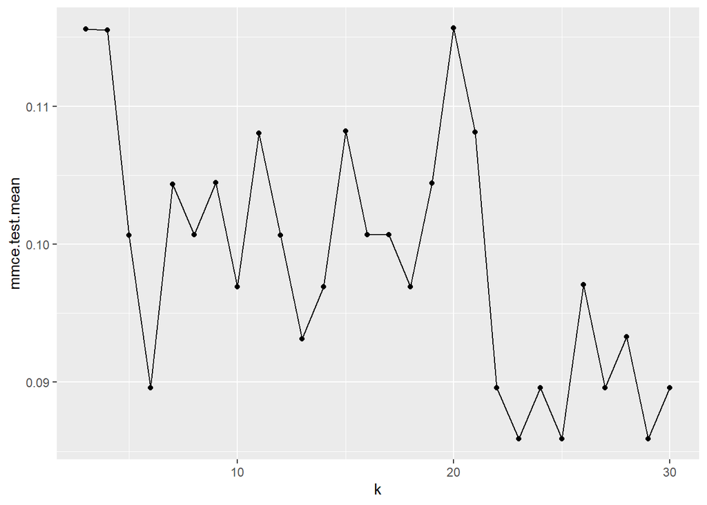

```r
OptimKNNres <- generateHyperParsEffectData(OptimKNN)

plotHyperParsEffect(OptimKNNres,
                    x = "k",
                    y = "mmce.test.mean",
                    plot.type = "line")
```

**Saame siit teada, et täpseima klassifitseerimistulemuse annab milline k väärtus?**

Teeme tulemuse põhjal klassifitseerimisprotsessi näitlikult lõpuni läbi ja treenime lõpliku mudeli (kui peame optimaalseks **k** väärtuseks midagi muud kui see, millel on väikseim *mmce* väärtus, saab selle järgnevas käsus kirja panna nt k = 45 puhul par.vals = list(k = 45)).

```r
TunedKNN <- setHyperPars(makeLearner("classif.knn"), par.vals = OptimKNN$x)

TunedKnnModel <- train(TunedKNN, lr_valid)
TunedKnnModel
```

```
## Model for learner.id=classif.knn; learner.class=classif.knn
## Trained on: task.id = df; obs = 268; features = 2
## Hyperparameters: k=23
```

Objektis `TunedKnnModel` on mudel, mida saaksime edaspidi kasutada uutel andmetel, kus klassikuuluvuse tunnust ei ole, st päris andmetel, kus on erakondade kohta hinnangud maksu- ja immigratsiooniküsimustes ilma teabeta, kas tegu on vasak- või parempoolse erakonnaga. Selleks saab kasutada juba eelnevalt kasutatud funktsiooni `predict`, kus argumendile `newdata` omistatakse uus andmestik:

```r
# knnProgn <- predict(TunedKnnModel, newdata = ...)
```

Lõpuks võib öelda, et võib-olla kõige parema täpsusega meie mudel ei ole. Nimelt kannatab KNN meetod sellise nähtuse all nagu “mitmedimensionaalsuse needus” (*curse of multidimensionality*). Kui meil on väga palju tunnuseid, siis sellisel juhul see KNN meetod ei pruugi suuta võimalikult täpselt prognoose anda - sellisel juhul oleks hea kasutada mingi piiratud arv tunnuseid või siis kuidagi agregeerida neid andmeid.